# Linear Regression (ISL 3)

Biostat 274

Author

Dr. Jin Zhou @ UCLA

Published

January 14, 2026

Credit: This note heavily uses material from the books [*An Introduction to Statistical Learning: with Applications in R*](https://www.statlearning.com/) (ISL2) and [*Elements of Statistical Learning: Data Mining, Inference, and Prediction*](https://hastie.su.domains/ElemStatLearn/) (ESL2).

Display system information for reproducibility.

**R**

**Python**

```python
import IPython
print(IPython.sys_info())
```

```
{'commit_hash': '5ed988a91',
 'commit_source': 'installation',
 'default_encoding': 'utf-8',
 'ipython_path': '/Users/jinjinzhou/.virtualenvs/r-tensorflow/lib/python3.10/site-packages/IPython',
 'ipython_version': '8.33.0',
 'os_name': 'posix',
 'platform': 'macOS-15.7.3-arm64-arm-64bit',
 'sys_executable': '/Users/jinjinzhou/.virtualenvs/r-tensorflow/bin/python',
 'sys_platform': 'darwin',
 'sys_version': '3.10.16 (main, Mar  3 2025, 20:01:33) [Clang 16.0.0 '
                '(clang-1600.0.26.6)]'}
```

## 1 Linear regression in this course: a modern ML baseline

Many of you have already learned linear regression as a *statistical* tool (estimation, confidence intervals, $t$-tests, $F$-tests, interpretation). In this course, we start with linear regression as a **machine learning algorithm**.

- **Task:** supervised learning (regression).
- **Goal:** accurate prediction on *new, unseen* data (**generalization**).
- **Why:** it is fast, surprisingly strong, and a foundation for many modern methods (regularization, kernels, neural networks). Understanding linear methods is essential for understanding nonlinear ones.

### 1.1 The supervised learning pipeline

We will repeatedly use the same template throughout the course:

1. **Data:** features $X \in \mathbb{R}^{n\times p}$ and targets $y \in \mathbb{R}^n$.
2. **Model family:** $f_\beta(x)$ (here: linear functions).
3. **Loss:** $\ell(y, f_\beta(x))$ (here: squared error).
4. **Optimization / learning:** choose $\hat\beta$ to minimize training loss.
5. **Evaluation:** estimate test performance with a train/test split or cross-validation.

## 2 Linear regression

- Linear regression is a simple approach to supervised learning. It assumes that the dependence of $Y$ on $X_1, X_2, \ldots, X_p$ is linear.
- True regression functions are never linear!
- Although it may seem overly simplistic, linear regression is extremely useful both conceptually and practically.

> Essentially, all models are wrong, but some are useful.

> George Box

## 3 `Advertising` data

- Response variable: `sales` (in thousands of units).
- Predictor variables:
  - `TV`: budget for TV advertising (in thousands of dollars).
  - `radio`: budget for radio advertising (in thousands of dollars).
  - `newspaper`: budget for newspaper advertising (in thousands of dollars).

**R**

```r
library(GGally) # ggpairs function
library(tidyverse)

# Advertising
Advertising <- read_csv("./slides/data/Advertising.csv",  col_select = TV:sales) %>%
  print(width = Inf)
```

```
# A tibble: 200 × 4
      TV radio newspaper sales
   <dbl> <dbl>     <dbl> <dbl>
 1 230.   37.8      69.2  22.1
 2  44.5  39.3      45.1  10.4
 3  17.2  45.9      69.3   9.3
 4 152.   41.3      58.5  18.5
 5 181.   10.8      58.4  12.9
 6   8.7  48.9      75     7.2
 7  57.5  32.8      23.5  11.8
 8 120.   19.6      11.6  13.2
 9   8.6   2.1       1     4.8
10 200.    2.6      21.2  10.6
# ℹ 190 more rows
```

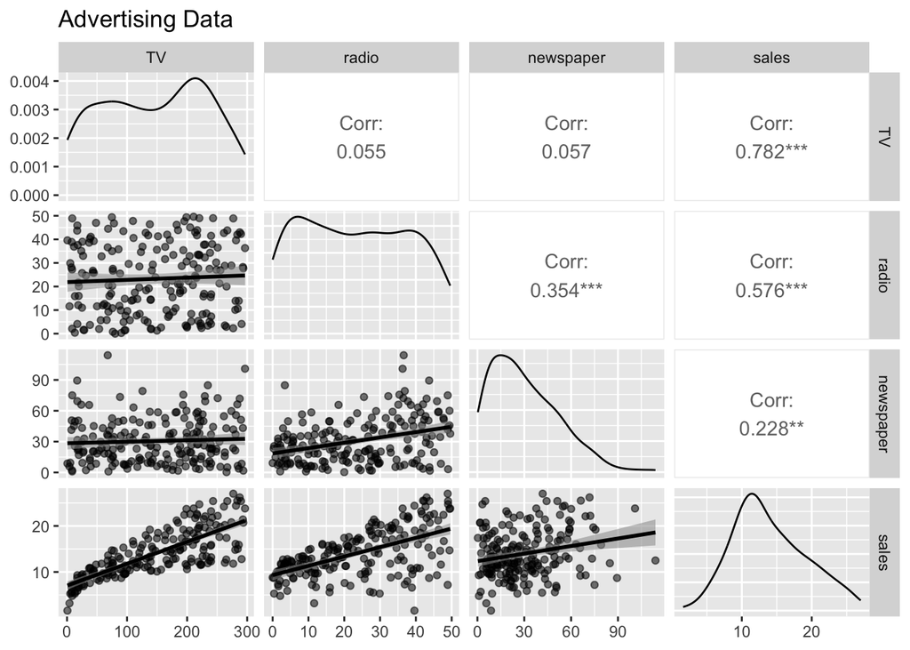

```r
# Visualization by pair plot
ggpairs(
  data = Advertising,
  mapping = aes(alpha = 0.25),
  lower = list(continuous = "smooth")
  ) +
  labs(title = "Advertising Data")
```

**Python**

```python
# Load the pandas library
import pandas as pd
# Load numpy for array manipulation
import numpy as np
# Load seaborn plotting library
import seaborn as sns
import matplotlib.pyplot as plt

# Set font sizes in plots
sns.set(font_scale = 2)
# Display all columns
pd.set_option('display.max_columns', None)

# Import Advertising data
Advertising = pd.read_csv("./slides/data/Advertising.csv", index_col = 0)
Advertising
```

```
        TV  radio  newspaper  sales
1    230.1   37.8       69.2   22.1
2     44.5   39.3       45.1   10.4
3     17.2   45.9       69.3    9.3
4    151.5   41.3       58.5   18.5
5    180.8   10.8       58.4   12.9
..     ...    ...        ...    ...
196   38.2    3.7       13.8    7.6
197   94.2    4.9        8.1    9.7
198  177.0    9.3        6.4   12.8
199  283.6   42.0       66.2   25.5
200  232.1    8.6        8.7   13.4

[200 rows x 4 columns]
```

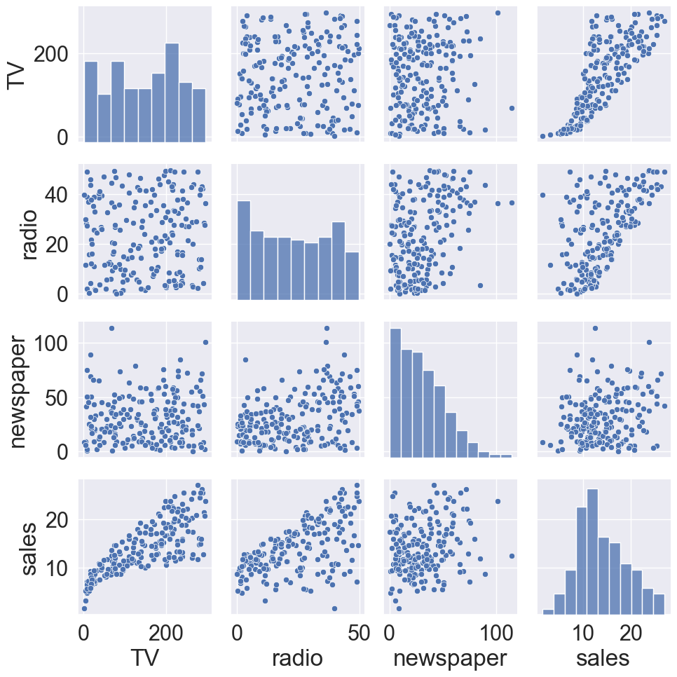

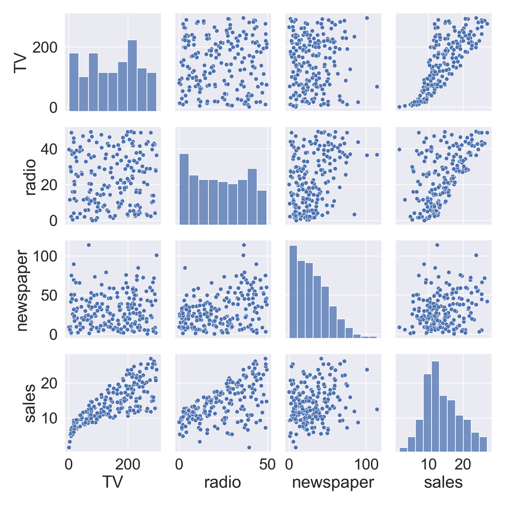

```python
# Visualization by pair plot
sns.pairplot(data = Advertising)
```

- A few questions we might ask
  - Is there a relationship between advertising budget and sales?
  - How strong is the relationship between advertising budget and sales?
  - Which media contribute to sales?
  - How accurately can we predict future sales?
  - Is the relationship linear?
  - Is there synergy among the advertising media?

## 4 Recall

- Data: observe a collection of i.i.d. training data, $\mathcal{D}_n = \{(\mathbf{x}_i, y_i)\}_{i=1}^n$ where $\mathbf{x}_i$ is a $p$-dimensional predictor vector, and $y_i \in \mathbb{R}$ is a continuous response.
- A loss function $L$ measures discrepancy between $Y$ and $f(X)$. A commonly used loss is **squared error loss**. And the expected loss over the population is
  $$R(f) = \mathbb{E}\,L\bigl(Y, f(X)\bigr) = \mathbb{E}\left[(Y - f(X))^2\right].$$
- With training data $\mathcal{D}_n$, we minimize **empirical risk** by replacing the expectation with an average:
  $$\frac{1}{n}\sum_{i=1}^n L\bigl(y_i, f(x_i)\bigr).$$
  Using squared error, choose $\hat f$ to minimize:
  $$\hat f = \arg\min_{f\in\mathcal{F}} \sum_{i=1}^n \bigl(y_i - f(x_i)\bigr)^2,$$
  where $\mathcal{F}$ is the model class we consider.

## 5 Simple linear regression vs multiple linear regression

- In **simple linear regression**, we assume a model
  $$Y = \underbrace{\beta_0}_{\text{intercept}} + \underbrace{\beta_1}_{\text{slope}} X + \epsilon.$$
  For example
  $$\text{sale} \approx \beta_0 + \beta_1 \times \text{TV}.$$
  The lower left plot in the pair plot (R) displays the fitted line
  $$\hat y = \hat \beta_0 + \hat \beta_1 \times \text{TV}.$$
- In **multiple linear regression**, we assume the model
  $$Y = \beta_0 + \beta_1 X_1 + \beta_2 X_2 + \cdots + \beta_p X_p + \epsilon.$$
  For example,
  $$\text{sales} \approx \beta_0 + \beta_1 \times \text{TV} + \beta_2 \times \text{radio} + \cdots + \beta_3 \times \text{newspaper}.$$

## 6 Estimation in multiple linear regression

- We estimate regression coefficients $\beta_0, \beta_1, \ldots, \beta_p$ by the **method of least squares**, which minimizes the sum of squared residuals
  $$\text{RSS} = \sum_{i=1}^n (y_i - \hat y_i)^2 = \sum_{i=1}^n (y_i - \beta_0 - \beta_1 x_{i1} - \cdots - \beta_p x_{ip})^2.$$
  From a machine learning perspective, least squares is **empirical risk minimization (ERM)** with *squared loss*.
- This loss is smooth and convex for linear models, which makes optimization and analysis convenient.

### 6.1 Closed form vs optimization

- For linear regression, the ERM problem has a closed-form solution. However, in modern machine learning we often fit models by **gradient-based optimization**, because it scales well to large datasets and extends directly to regularized models and neural networks.
- If we write $\mathbf{X}_{n\times{(p+1)}}$ for the design matrix and minimize
  $$\begin{align*}
  L(\beta) & =\frac{1}{n}\|y-X\beta\|_2^2\\
  & = \frac{1}{n}(y-X\beta)^T(y-X\beta)
  \end{align*}$$
  the gradient of $L$ is
  $$\begin{align*}
  \nabla_\beta L(\beta) & = -\frac{2}{n}X^T\,(y-X\beta)\\
  & \propto X^T X \beta - X^T y.
  \end{align*}$$
  We solve for $\beta$ by setting the gradient to zero:
  $$X^T X \beta = X^T y$$
- The minimizer $\hat \beta_0, \hat \beta_1, \ldots, \hat \beta_p$ admits the analytical solution
  $$\hat \beta = (\mathbf{X}^T \mathbf{X})^{-1} \mathbf{X}^T \mathbf{y}.$$
- $X$ full rank $\Longleftrightarrow$ $X^\mathsf{T}X$ invertible.
- In general we solve $\nabla_\beta L(\beta) = 0$ for $\beta$ and the gradient descent updates are
  $$\beta^{(t+1)}=\beta^{(t)}-\eta\,\nabla_\beta L(\beta^{(t)}).$$
  where $\eta$ is the step size (learning rate).

**R**

```r
library(gtsummary)

# Linear regression
lmod <- lm(sales ~ TV + radio + newspaper, data = Advertising)
summary(lmod)
```

```
Call:
lm(formula = sales ~ TV + radio + newspaper, data = Advertising)

Residuals:
    Min      1Q  Median      3Q     Max
-8.8277 -0.8908  0.2418  1.1893  2.8292

Coefficients:
             Estimate Std. Error t value Pr(>|t|)
(Intercept)  2.938889   0.311908   9.422   <2e-16 ***
TV           0.045765   0.001395  32.809   <2e-16 ***
radio        0.188530   0.008611  21.893   <2e-16 ***
newspaper   -0.001037   0.005871  -0.177     0.86
---
Signif. codes:  0 '***' 0.001 '**' 0.01 '*' 0.05 '.' 0.1 ' ' 1

Residual standard error: 1.686 on 196 degrees of freedom
Multiple R-squared:  0.8972,    Adjusted R-squared:  0.8956
F-statistic: 570.3 on 3 and 196 DF,  p-value: < 2.2e-16
```

```r
# Better summary table
lmod %>%
  tbl_regression() %>%
  bold_labels() %>%
  bold_p(t = 0.05)
```

| **Characteristic** | **Beta** | **95% CI** | **p-value** |
| --- | --- | --- | --- |
| TV | 0.05 | 0.04, 0.05 | <0.001 |
| radio | 0.19 | 0.17, 0.21 | <0.001 |
| newspaper | 0.00 | -0.01, 0.01 | 0.9 |

Abbreviation: CI = Confidence Interval

**Python (sklearn)**

```python
# sklearn does not offer much besides coefficient estimate
from sklearn.linear_model import LinearRegression

X = Advertising[['TV', 'radio', 'newspaper']]
y = Advertising['sales']
lmod = LinearRegression().fit(X, y)
lmod.intercept_
```

```
np.float64(2.9388893694594085)
```

```python
lmod.coef_
```

```
array([ 0.04576465,  0.18853002, -0.00103749])
```

```python
# Score is the R^2
lmod.score(X, y)
```

```
0.8972106381789522
```

**Python (statsmodels)**

```python
import statsmodels.api as sm
import statsmodels.formula.api as smf

# Fit linear regression
lmod = smf.ols(formula = 'sales ~ TV + radio + newspaper', data = Advertising).fit()
lmod.summary()
```

OLS Regression Results

| Dep. Variable: | sales | R-squared: | 0.897 |
| --- | --- | --- | --- |
| Model: | OLS | Adj. R-squared: | 0.896 |
| Method: | Least Squares | F-statistic: | 570.3 |
| Date: | Wed, 14 Jan 2026 | Prob (F-statistic): | 1.58e-96 |
| Time: | 09:00:36 | Log-Likelihood: | -386.18 |
| No. Observations: | 200 | AIC: | 780.4 |
| Df Residuals: | 196 | BIC: | 793.6 |
| Df Model: | 3 |  |  |
| Covariance Type: | nonrobust |  |  |

|  | coef | std err | t | P>\|t\| | [0.025 | 0.975] |
| --- | --- | --- | --- | --- | --- | --- |
| Intercept | 2.9389 | 0.312 | 9.422 | 0.000 | 2.324 | 3.554 |
| TV | 0.0458 | 0.001 | 32.809 | 0.000 | 0.043 | 0.049 |
| radio | 0.1885 | 0.009 | 21.893 | 0.000 | 0.172 | 0.206 |
| newspaper | -0.0010 | 0.006 | -0.177 | 0.860 | -0.013 | 0.011 |

| Omnibus: | 60.414 | Durbin-Watson: | 2.084 |
| --- | --- | --- | --- |
| Prob(Omnibus): | 0.000 | Jarque-Bera (JB): | 151.241 |
| Skew: | -1.327 | Prob(JB): | 1.44e-33 |
| Kurtosis: | 6.332 | Cond. No. | 454. |

Notes:  
[1] Standard Errors assume that the covariance matrix of the errors is correctly specified.

**R**

```r
set.seed(1)
n <- nrow(Advertising)
idx <- sample.int(n, size = floor(0.8*n))

train <- Advertising[idx, ]
test  <- Advertising[-idx, ]

fit <- lm(sales ~ TV + radio + newspaper, data = train)
pred <- predict(fit, newdata = test)

mse  <- mean((test$sales - pred)^2)
rmse <- sqrt(mse)
c(MSE = mse, RMSE = rmse)
```

```
     MSE     RMSE
3.416998 1.848512
```

**Python (sklearn)**

```python
from sklearn.model_selection import train_test_split
from sklearn.linear_model import LinearRegression
from sklearn.metrics import mean_squared_error, r2_score

X = Advertising[['TV', 'radio', 'newspaper']]
y = Advertising['sales']

X_train, X_test, y_train, y_test = train_test_split(
    X, y, test_size=0.2, random_state=1
)

model = LinearRegression().fit(X_train, y_train)
pred = model.predict(X_test)

mse  = mean_squared_error(y_test, pred)
rmse = mse**0.5
r2   = r2_score(y_test, pred)

{"MSE": mse, "RMSE": rmse, "R2": r2}
```

```
{'MSE': 1.99188555182879, 'RMSE': 1.4113417558581585, 'R2': 0.8927605914615384}
```

## 7 Statistical Properties of $\hat\beta$

Assume data are generated from:
$$Y = X^\mathsf{T}\beta + \varepsilon,$$
with $\varepsilon_i$ i.i.d., $\mathbb{E}(\varepsilon_i)=0$, $\mathrm{Var}(\varepsilon_i)=\sigma^2$. Then:

- **Unbiasedness**: $\mathbb{E}(\hat\beta) = \beta$
- **Variance–covariance**:
  $$\mathrm{Var}(\hat\beta) = (X^\mathsf{T}X)^{-1}\sigma^2$$
- **Gauss–Markov theorem**: $\hat\beta$ is the **BLUE** (best linear unbiased estimator).
- The **residuals** are the differences between the observed and predicted values:
  $$e_i = y_i - \hat y_i = y_i - X_i^\mathsf{T}\hat\beta.$$
- An unbiased estimator of $\sigma^2$ is
  $$\hat \sigma^2 = \frac{1}{n - p-1} \sum_{i=1}^n e_i^2 = \frac{\text{RSS}}{n - p-1}.$$

## 8 Variable Selection: Dealing with Large $p$

- In many applications, we have many explanatory variables (large $p$, even $p \gg n$):
  - $>20,000$ human protein-coding genes
  - ~10 million SNPs
  - $n$ often in hundreds or thousands
- Bias-variance trade off: identify a subset of $\mathbf{X}$ variables most relevant to $\mathbf{Y}$
- Inadequate to look at marginal effects alone (e.g., p-values).

### 8.1 Training vs. Testing Error (Setup)

Training data $\mathcal{D}_n=\{(x_i,y_i)\}_{i=1}^n$.

Suppose an (imaginary) independent testing dataset $\{(x_i, y_i^*)\}_{i=1}^n$ is collected at the **same** locations $x_i$ (in-sample prediction).

Assume data are from a linear model:
$$y = \mu + e = X\beta + e,\qquad
y^* = \mu + e^* = X\beta + e^*,$$
where $e$ and $e^*$ are i.i.d. with mean 0 and variance $\sigma^2$.

The true model is indeed linear.

### 8.2 Training vs. Testing Error (Results)

Testing error:
$$\mathbb{E}[\mathrm{Test\, MSE}] =\frac{1}{n} \mathbb{E}\|y^* - X\hat\beta\|_2^2
= \left (1+\frac{p}{n}\right)\sigma^2.$$

Training error:
$$\mathbb{E}[\mathrm{Train\ MSE}] = \frac{1}{n} \mathbb{E}\|y-\hat y\|_2^2
= \left (1-\frac{p}{n}\right)\sigma^2.$$

So, testing error **increases** with $p$ while training error **decreases** with $p$.  
When $p$ is large, this becomes troublesome.

### 8.3 Conclusion

Hence, selecting a set of relevant variables is necessary, especially when $p$ is large.

Variable selection may improve:

- Prediction accuracy
- Interpretability

Difficulties:

- No natural ordering of variable importance
- Importance depends on conditioning on other variables; high correlation causes trouble
- Checking all combinations can be computationally infeasible

## 9 Model Selection

Model selection is usually done by:

1. Give each model a **score**
2. Use an algorithm to find the model with the best (smallest) score

A typical score has the form:

**Goodness-of-fit + Complexity penalty**

- Fit term decreases as model becomes more complex
- Penalty increases with number of predictors, favoring smaller models

### 9.1 ML approach: validation and cross-validation

In machine learning, *model selection* is usually framed as choosing **hyperparameters** (e.g., which features to include, degree of a polynomial, or the regularization strength) by minimizing an estimate of **test error**.

A standard approach is **$K$-fold cross-validation**.

### 9.2 Subset selection

- For a naive implementation of the best subset, forward selection, and backward selection regressions in Python, interesting readers can read this [blog](https://xavierbourretsicotte.github.io/subset_selection.html).

#### 9.2.1 Best subset regression

- The most direct approach is called **all subsets** or **best subsets** regression: we compute the least squares fit for all possible subsets and then choose between them based on some criterion that balances training error with model size.
- We try the highly-optimized [`abess`](https://abess.readthedocs.io/en/latest/index.html) package here.

**R**

```r
library(leaps)

bs_mod <- regsubsets(
  sales ~ .,
  data = Advertising,
  method = "exhaustive"
  ) %>% summary()
bs_mod
```

```
Subset selection object
Call: regsubsets.formula(sales ~ ., data = Advertising, method = "exhaustive")
3 Variables  (and intercept)
          Forced in Forced out
TV            FALSE      FALSE
radio         FALSE      FALSE
newspaper     FALSE      FALSE
1 subsets of each size up to 3
Selection Algorithm: exhaustive
         TV  radio newspaper
1  ( 1 ) "*" " "   " "
2  ( 1 ) "*" "*"   " "
3  ( 1 ) "*" "*"   "*"
```

```r
tibble(
  K = 1:3,
  R2 = bs_mod$rsq,
  adjR2 = bs_mod$adjr2,
  BIC = bs_mod$bic,
  CP = bs_mod$cp
) %>% print(width = Inf)
```

```
# A tibble: 3 × 5
      K    R2 adjR2   BIC     CP
  <int> <dbl> <dbl> <dbl>  <dbl>
1     1 0.612 0.610 -179. 544.
2     2 0.897 0.896 -439.   2.03
3     3 0.897 0.896 -434.   4
```

**Python**

```python
from abess.linear import LinearRegression
from patsy import dmatrices

# Create design matrix and response vector using R-like formula
ym, Xm = dmatrices(
  'sales ~ TV + radio + newspaper',
  data = Advertising,
  return_type = 'matrix'
  )
lmod_abess = LinearRegression(support_size = range(3))
lmod_abess.fit(Xm, ym)
lmod_abess.coef_
```

[output not shown]

- However we often can’t examine all possible models, since there are $2^p$ of them. For example, when $p = 30$, there are $2^{30} = 1,073,741,824$ models!
- Recent advances make possible to solve best subset regression with $p \sim 10^3 \sim 10^5$ with high-probability guarantee of optimality. See this [article](https://doi.org/10.1073/pnas.2014241117).
- For really big $p$, we need some heuristic approaches to search through a subset of them. We discuss three commonly use approaches next.

#### 9.2.2 Forward selection

- Begin with the **null model**, a model that contains an intercept but no predictors.
- Fit $p$ simple linear regressions and add to the null model the variable that results in the lowest RSS (equivalently the lowest AIC).
- Add to that model the variable that results in the lowest RSS among all two-variable models.
- Continue until some stopping rule is satisfied, for example when the AIC does not decrease anymore.

**R**

```r
lmod_null <- lm(sales ~ 1, data = Advertising)
step(lmod_null,
     scope = list(lower = sales ~ 1, upper = sales ~ TV + radio + newspaper),
     trace = TRUE,
     direction = "forward"
    )
```

```
Start:  AIC=661.8
sales ~ 1

            Df Sum of Sq    RSS    AIC
+ TV         1    3314.6 2102.5 474.52
+ radio      1    1798.7 3618.5 583.10
+ newspaper  1     282.3 5134.8 653.10
<none>                   5417.1 661.80

Step:  AIC=474.52
sales ~ TV

            Df Sum of Sq     RSS    AIC
+ radio      1   1545.62  556.91 210.82
+ newspaper  1    183.97 1918.56 458.20
<none>                   2102.53 474.52

Step:  AIC=210.82
sales ~ TV + radio

            Df Sum of Sq    RSS    AIC
<none>                   556.91 210.82
+ newspaper  1  0.088717 556.83 212.79
```

```
Call:
lm(formula = sales ~ TV + radio, data = Advertising)

Coefficients:
(Intercept)           TV        radio
    2.92110      0.04575      0.18799
```

#### 9.2.3 Backward selection

- Start with all variables in the model.
- Remove the variable with the largest $p$-value. That is the variable that is the least statistically significant.
- The new $(p-1)$-variable model is fit, and the variable with the largest p-value is removed.
- Continue until a stopping rule is reached. For instance, we may stop when AIC does not decrease anymore, or when all remaining variables have a significant $p$-value defined by some significance threshold.
- Backward selection cannot start with a model with $p > n$.

**R**

```r
step(lmod,
     scope = list(lower = sales ~ 1, upper = sales ~ TV + radio + newspaper),
     trace = TRUE,
     direction = "backward"
     )
```

```
Start:  AIC=212.79
sales ~ TV + radio + newspaper

            Df Sum of Sq    RSS    AIC
- newspaper  1      0.09  556.9 210.82
<none>                    556.8 212.79
- radio      1   1361.74 1918.6 458.20
- TV         1   3058.01 3614.8 584.90

Step:  AIC=210.82
sales ~ TV + radio

        Df Sum of Sq    RSS    AIC
<none>                556.9 210.82
- radio  1    1545.6 2102.5 474.52
- TV     1    3061.6 3618.5 583.10
```

```
Call:
lm(formula = sales ~ TV + radio, data = Advertising)

Coefficients:
(Intercept)           TV        radio
    2.92110      0.04575      0.18799
```

#### 9.2.4 Mixed selection

- We alternately perform forward and backward steps until all variables in the model have a sufficiently low $p$-value, and all variables outside the model would have a large $p$-value if added to the model.

**R**

```r
step(lmod_null,
     scope = list(lower = sale ~ 1, upper = sale ~ TV + radio + newspaper),
     trace = TRUE,
     direction = "both"
     )
```

```
Start:  AIC=661.8
sales ~ 1

            Df Sum of Sq    RSS    AIC
+ TV         1    3314.6 2102.5 474.52
+ radio      1    1798.7 3618.5 583.10
+ newspaper  1     282.3 5134.8 653.10
<none>                   5417.1 661.80

Step:  AIC=474.52
sales ~ TV

            Df Sum of Sq    RSS    AIC
+ radio      1    1545.6  556.9 210.82
+ newspaper  1     184.0 1918.6 458.20
<none>                   2102.5 474.52
- TV         1    3314.6 5417.1 661.80

Step:  AIC=210.82
sales ~ TV + radio

            Df Sum of Sq    RSS    AIC
<none>                    556.9 210.82
+ newspaper  1      0.09  556.8 212.79
- radio      1   1545.62 2102.5 474.52
- TV         1   3061.57 3618.5 583.10
```

```
Call:
lm(formula = sales ~ TV + radio, data = Advertising)

Coefficients:
(Intercept)           TV        radio
    2.92110      0.04575      0.18799
```

#### 9.2.5 Other model selection criteria

Commonly used model selection criteria include Mallow’s $C_p$, Akaike information criterion (AIC), Bayesian information criterion (BIC), and adjusted $R^2$.

- As we saw earlier, the training set MSE is generally an underestimate of the test MSE. Therefore the training RSS and $R^2$ may not be used for selecting the best model unless we adjust for this underestimation.
- Mallow’s $C_p$ is an estimate of the test MSE that adjusts for the bias in the training MSE:
  $$C_p = \frac{1}{n}(\text{RSS} + 2d\hat\sigma^2),$$
  where $d$ is the number of predictors in the model (including the intercept) and $\hat\sigma^2$ is an estimate of the variance of the error terms.
- AIC is defined as
  $$\text{AIC} = \frac{1}{n\hat\sigma^2}(\text{RSS} + 2d\hat\sigma^2).$$
- BIC is defined as
  $$\text{BIC} = \frac{1}{n}(\text{RSS} + \log(n)d\hat\sigma^2).$$
- Both AIC and BIC impose a penalty for model complexity. BIC imposes a larger penalty than AIC when $n$ is large.

## 10 Model fit

**Question:** How well does the selected model fit the data?

- **$R^2$**: the fraction of variance explained
  $$R^2 = 1 - \frac{\text{RSS}}{\text{TSS}} = 1 - \frac{\sum_i (y_i - \hat y_i)^2}{\sum_i (y_i - \bar y)^2}.$$
  It turns out (HW1 bonus question)
  $$R^2 = \operatorname{Cor}(Y, \hat Y)^2.$$
  Adding more predictors into a model **always** increase $R^2$.
- From computer output, we see the fitted linear model by using `TV`, `radio`, and `newspaper` has an $R^2=0.8972$.

**R**

```r
# R^2
summary(lmod)$r.squared
```

```
[1] 0.8972106
```

```r
# Cor(Y, \hat Y)^2
cor(predict(lmod), Advertising$sales)^2
```

```
[1] 0.8972106
```

**Python**

```python
# R^2
lmod.rsquared
```

```
np.float64(0.8972106381789522)
```

```python
# Cor(Y, \hat Y)^2
np.corrcoef(Advertising['sales'], lmod.predict())
```

```
array([[1.        , 0.94721203],
       [0.94721203, 1.        ]])
```

```python
np.corrcoef(Advertising['sales'], lmod.predict())[0, 1]**2
```

```
np.float64(0.8972106381789523)
```

- The **adjusted $R_a^2$** adjusts to the fact that a larger model also uses more parameters.
  $$R_a^2 = 1 - \frac{\text{RSS}/(n-p-1)}{\text{TSS}/(n-1)}.$$
  Adding a predictor will only increase $R_a^2$ if it has some predictive value.

**R**

```r
# Adjusted R^2
summary(lmod)$adj.r.squared
```

```
[1] 0.8956373
```

**Python**

```python
# Adjusted R^2
lmod.rsquared_adj
```

```
np.float64(0.8956373316204668)
```

- The **rooted squared error (RSE)**
  $$\text{RSE} = \sqrt{\frac{\text{RSS}}{n - p - 1}}$$
  is an estimator of the noise standard error $\sqrt{\operatorname{Var}(\epsilon)}$. The smaller RSE, the better fit of the model.

### 10.1 Prediction

**Question:** Given a set of predictor values, what response value should we predict, and how accurate is our prediction?

- Given a new set of predictors $x$, we predict $y$ by
  $$\hat y = \hat \beta_0 + \hat \beta_1 x_1 + \cdots + \hat \beta_p x_p.$$
- Under the selected model
  $$\text{sales} \approx \beta_0 + \beta_1 \times \text{TV} + \beta_2 \times \text{radio},$$
  how many units of sale do we expect with $100k budget in `TV` and $20k budget in `radio`?

**R**

```r
x_new <- list(TV = 100, radio = 20)
lmod_small <- lm(sales ~ TV + radio, data = Advertising)
predict(lmod_small, x_new, interval = "confidence")
```

```
       fit      lwr      upr
1 11.25647 10.98525 11.52768
```

```r
predict(lmod_small, x_new, interval = "prediction")
```

```
       fit      lwr      upr
1 11.25647 7.929616 14.58332
```

**Python**

```python
from patsy import dmatrices
# Create design matrix and response vector using R-like formula
y_small, X_small = dmatrices(
  'sales ~ TV + radio',
  data = Advertising,
  return_type = 'dataframe'
  )
# Fit linear regression
lmod_small = sm.OLS(y_small, X_small).fit()
lmod_small_pred = lmod_small.get_prediction(pd.DataFrame({'Intercept': [1], 'TV': [100], 'radio': [20]})).summary_frame()
lmod_small_pred
```

```
        mean   mean_se  mean_ci_lower  mean_ci_upper  obs_ci_lower  \
0  11.256466  0.137526      10.985254      11.527677      7.929616

   obs_ci_upper
0     14.583316
```

- 95% **Confidence interval**: probability of covering the true $f(X)$ is 0.95.
- 95% **Predictive interval**: probability of covering the true $Y$ is 0.95.

  Predictive interval is always wider than the confidence interval because it incorporates the randomness in both $\hat \beta$ and $\epsilon$.

## 11 Qualitative (or categorical) predictors

- In the `Advertising` data, all predictors are quantitative (or continuous).
- The `Credit` data has a mix of quantitative (`Balance`, `Age`, `Cards`, `Education`, `Income`, `Limit`, `Rating`) and qualitative predictors (`Own`, `Student`, `Married`, `Region`).
  - `balance`: average credit card debt for each individual
  - quantitative predictors: `age`, `cards` (number of credit cards), `education` (years of education), `income` (in thousands of dollars), `limit` (credit limit), and `rating` (credit rating)
  - qualitative variables: `own` (house ownership), `student` (student status), `status` (marital status), and `region` (East, West or South).

**R**

```r
library(ISLR2)

# Credit
Credit <- as_tibble(Credit) %>% print(width = Inf)
```

```
# A tibble: 400 × 11
   Income Limit Rating Cards   Age Education Own   Student Married Region
    <dbl> <dbl>  <dbl> <dbl> <dbl>     <dbl> <fct> <fct>   <fct>   <fct>
 1   14.9  3606    283     2    34        11 No    No      Yes     South
 2  106.   6645    483     3    82        15 Yes   Yes     Yes     West
 3  105.   7075    514     4    71        11 No    No      No      West
 4  149.   9504    681     3    36        11 Yes   No      No      West
 5   55.9  4897    357     2    68        16 No    No      Yes     South
 6   80.2  8047    569     4    77        10 No    No      No      South
 7   21.0  3388    259     2    37        12 Yes   No      No      East
 8   71.4  7114    512     2    87         9 No    No      No      West
 9   15.1  3300    266     5    66        13 Yes   No      No      South
10   71.1  6819    491     3    41        19 Yes   Yes     Yes     East
   Balance
     <dbl>
 1     333
 2     903
 3     580
 4     964
 5     331
 6    1151
 7     203
 8     872
 9     279
10    1350
# ℹ 390 more rows
```

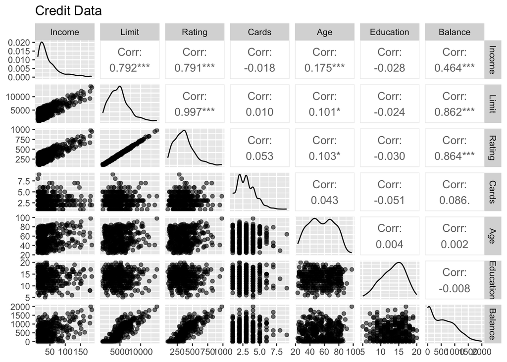

```r
# Pair plot of continuous predictors
ggpairs(
  data = Credit[, c(1:6, 11)],
  mapping = aes(alpha = 0.25)
  ) +
  labs(title = "Credit Data")
```

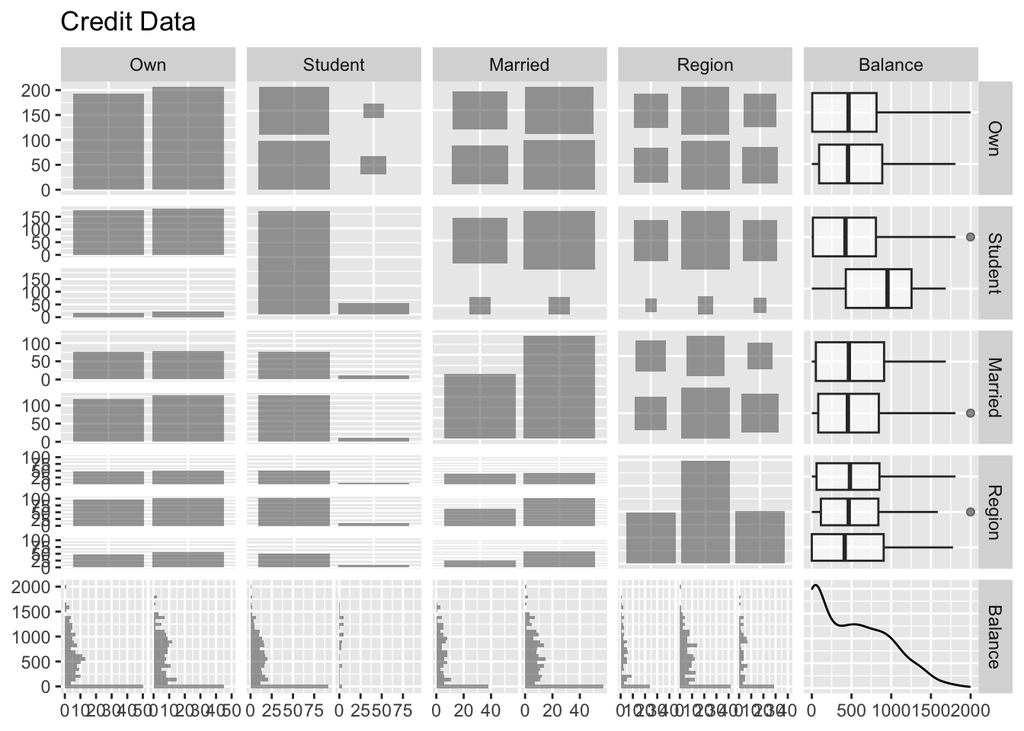

```r
# Pair plot of categorical predictors
ggpairs(
  data = Credit[, c(7:10, 11)],
  mapping = aes(alpha = 0.25)
  ) +
  labs(title = "Credit Data")
```

**Python**

```python
# Import Credit data
Credit = pd.read_csv("./slides/data/Credit.csv")
Credit
```

```
      Income  Limit  Rating  Cards  Age  Education  Own Student Married  \
0     14.891   3606     283      2   34         11   No      No     Yes
1    106.025   6645     483      3   82         15  Yes     Yes     Yes
2    104.593   7075     514      4   71         11   No      No      No
3    148.924   9504     681      3   36         11  Yes      No      No
4     55.882   4897     357      2   68         16   No      No     Yes
..       ...    ...     ...    ...  ...        ...  ...     ...     ...
395   12.096   4100     307      3   32         13   No      No     Yes
396   13.364   3838     296      5   65         17   No      No      No
397   57.872   4171     321      5   67         12  Yes      No     Yes
398   37.728   2525     192      1   44         13   No      No     Yes
399   18.701   5524     415      5   64          7  Yes      No      No

    Region  Balance
0    South      333
1     West      903
2     West      580
3     West      964
4    South      331
..     ...      ...
395  South      560
396   East      480
397  South      138
398  South        0
399   West      966

[400 rows x 11 columns]
```

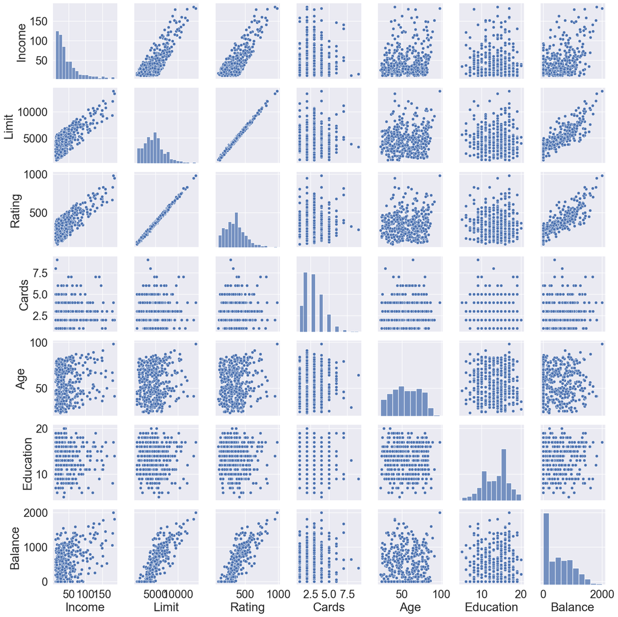

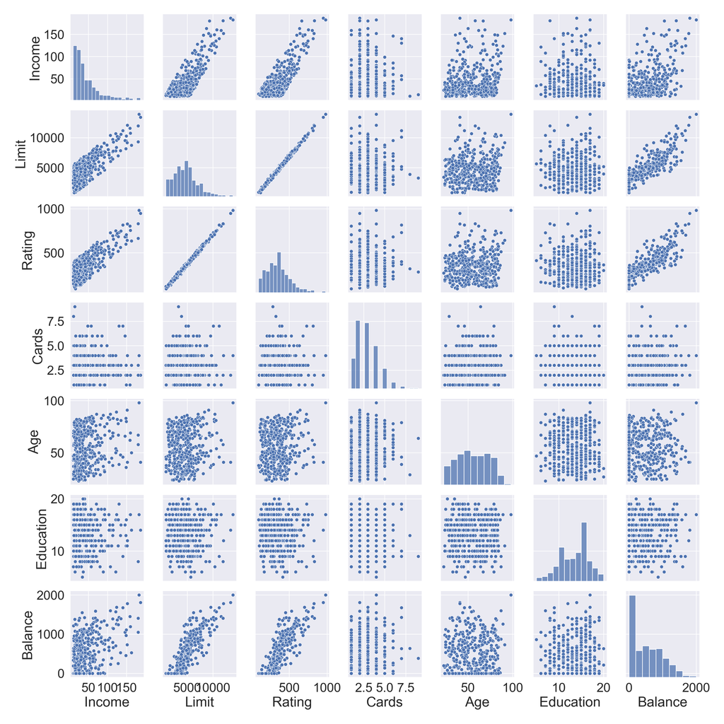

```python
# Visualization by pair plot
sns.pairplot(data = Credit)
```

- By default, most software create **dummy variables**, also called **one-hot coding**, for categorical variables. Both Python (statsmodels) and R use the first level (in alphabetical order) as the base level.
  - For example: `own` has two levels: `no` and `yes`. The dummy variable `own` is 1 if `own` is `yes` and 0 otherwise:
    $$x_i = \begin{cases}
    1 & \text{if own}_i = \text{yes, } \text{i.e., if ith person owns a house} \\
    0 & \text{if own}_i = \text{no, } \text{i.e., if ith person does not own a house}
    \end{cases}$$
    This results in the model
    $$y_i = \beta_0 + \beta_1x_i + \epsilon = \begin{cases}
    \beta_0 + \beta_1 + \epsilon & \text{if own}_i = \text{yes, } \text{i.e., if ith person owns a house} \\
    \beta_0 + \epsilon & \text{if own}_i = \text{no, } \text{i.e., if ith person does not own a house}
    \end{cases}$$
  - $\beta_0$: the average credit card balance among those who do not own
  - $\beta_0 + \beta_1$: the average credit card balance among those who do own their house
  - $\beta_1$: the average difference in credit card balance between owners and non-owners
  - Since the p-value for the dummy variable is very high, this indicates that there is no statistical evidence of a difference in average credit card balance based on house ownership.

**R**

```r
lm(Balance ~ ., data = Credit) %>%
  tbl_regression() %>%
  bold_labels() %>%
  bold_p(t = 0.05)
```

| **Characteristic** | **Beta** | **95% CI** | **p-value** |
| --- | --- | --- | --- |
| Income | -7.8 | -8.3, -7.3 | <0.001 |
| Limit | 0.19 | 0.13, 0.26 | <0.001 |
| Rating | 1.1 | 0.17, 2.1 | 0.021 |
| Cards | 18 | 9.2, 26 | <0.001 |
| Age | -0.61 | -1.2, -0.04 | 0.037 |
| Education | -1.1 | -4.2, 2.0 | 0.5 |
| Own |  |  |  |
| No | — | — |  |
| Yes | -11 | -30, 8.8 | 0.3 |
| Student |  |  |  |
| No | — | — |  |
| Yes | 426 | 393, 459 | <0.001 |
| Married |  |  |  |
| No | — | — |  |
| Yes | -8.5 | -29, 12 | 0.4 |
| Region |  |  |  |
| East | — | — |  |
| South | 10 | -14, 34 | 0.4 |
| West | 17 | -11, 45 | 0.2 |

Abbreviation: CI = Confidence Interval

**Python**

```python
# Hack to get all predictors
my_formula = "Balance ~ " + "+".join(Credit.columns.difference(["Balance"]))
# Create design matrix and response vector using R-like formula
y, X = dmatrices(
  my_formula,
  data = Credit,
  return_type = 'dataframe'
  )
# One-hot coding for categorical variables
X
```

```
     Intercept  Married[T.Yes]  Own[T.Yes]  Region[T.South]  Region[T.West]  \
0          1.0             1.0         0.0              1.0             0.0
1          1.0             1.0         1.0              0.0             1.0
2          1.0             0.0         0.0              0.0             1.0
3          1.0             0.0         1.0              0.0             1.0
4          1.0             1.0         0.0              1.0             0.0
..         ...             ...         ...              ...             ...
395        1.0             1.0         0.0              1.0             0.0
396        1.0             0.0         0.0              0.0             0.0
397        1.0             1.0         1.0              1.0             0.0
398        1.0             1.0         0.0              1.0             0.0
399        1.0             0.0         1.0              0.0             1.0

     Student[T.Yes]   Age  Cards  Education   Income   Limit  Rating
0               0.0  34.0    2.0       11.0   14.891  3606.0   283.0
1               1.0  82.0    3.0       15.0  106.025  6645.0   483.0
2               0.0  71.0    4.0       11.0  104.593  7075.0   514.0
3               0.0  36.0    3.0       11.0  148.924  9504.0   681.0
4               0.0  68.0    2.0       16.0   55.882  4897.0   357.0
..              ...   ...    ...        ...      ...     ...     ...
395             0.0  32.0    3.0       13.0   12.096  4100.0   307.0
396             0.0  65.0    5.0       17.0   13.364  3838.0   296.0
397             0.0  67.0    5.0       12.0   57.872  4171.0   321.0
398             0.0  44.0    1.0       13.0   37.728  2525.0   192.0
399             0.0  64.0    5.0        7.0   18.701  5524.0   415.0

[400 rows x 12 columns]
```

```python
# Fit linear regression
sm.OLS(y, X).fit().summary()
```

OLS Regression Results

| Dep. Variable: | Balance | R-squared: | 0.955 |
| --- | --- | --- | --- |
| Model: | OLS | Adj. R-squared: | 0.954 |
| Method: | Least Squares | F-statistic: | 750.3 |
| Date: | Wed, 14 Jan 2026 | Prob (F-statistic): | 1.11e-253 |
| Time: | 09:00:44 | Log-Likelihood: | -2398.7 |
| No. Observations: | 400 | AIC: | 4821. |
| Df Residuals: | 388 | BIC: | 4869. |
| Df Model: | 11 |  |  |
| Covariance Type: | nonrobust |  |  |

|  | coef | std err | t | P>\|t\| | [0.025 | 0.975] |
| --- | --- | --- | --- | --- | --- | --- |
| Intercept | -479.2079 | 35.774 | -13.395 | 0.000 | -549.543 | -408.873 |
| Married[T.Yes] | -8.5339 | 10.363 | -0.824 | 0.411 | -28.908 | 11.841 |
| Own[T.Yes] | -10.6532 | 9.914 | -1.075 | 0.283 | -30.145 | 8.839 |
| Region[T.South] | 10.1070 | 12.210 | 0.828 | 0.408 | -13.899 | 34.113 |
| Region[T.West] | 16.8042 | 14.119 | 1.190 | 0.235 | -10.955 | 44.564 |
| Student[T.Yes] | 425.7474 | 16.723 | 25.459 | 0.000 | 392.869 | 458.626 |
| Age | -0.6139 | 0.294 | -2.088 | 0.037 | -1.192 | -0.036 |
| Cards | 17.7245 | 4.341 | 4.083 | 0.000 | 9.190 | 26.259 |
| Education | -1.0989 | 1.598 | -0.688 | 0.492 | -4.241 | 2.043 |
| Income | -7.8031 | 0.234 | -33.314 | 0.000 | -8.264 | -7.343 |
| Limit | 0.1909 | 0.033 | 5.824 | 0.000 | 0.126 | 0.255 |
| Rating | 1.1365 | 0.491 | 2.315 | 0.021 | 0.171 | 2.102 |

| Omnibus: | 34.899 | Durbin-Watson: | 1.968 |
| --- | --- | --- | --- |
| Prob(Omnibus): | 0.000 | Jarque-Bera (JB): | 41.766 |
| Skew: | 0.782 | Prob(JB): | 8.52e-10 |
| Kurtosis: | 3.241 | Cond. No. | 3.87e+04 |

Notes:  
[1] Standard Errors assume that the covariance matrix of the errors is correctly specified.  
[2] The condition number is large, 3.87e+04. This might indicate that there are  
strong multicollinearity or other numerical problems.

- There are many different ways of coding qualitative variables, measuring particular **contrasts**.
  - For example, instead of 0/1 coding scheme, we could create a dummy variable as: `own` is 1 if `own` is `yes` and -1 otherwise:
    $$x_i = \begin{cases}
    1 & \text{if own}_i = \text{yes, } \text{i.e., if ith person owns a house} \\
    -1 & \text{if own}_i = \text{no, } \text{i.e., if ith person does not own a house}
    \end{cases}$$
    This results in the model
    $$y_i = \beta_0 + \beta_1x_i + \epsilon = \begin{cases}
    \beta_0 + \beta_1 + \epsilon & \text{if own}_i = \text{yes, } \text{i.e., if ith person owns a house} \\
    \beta_0 -\beta_1 \epsilon & \text{if own}_i = \text{no, } \text{i.e., if ith person does not own a house}
    \end{cases}$$
  - Question: how to interpret $\beta_0$ and $\beta_1$?

### 11.1 More than two levels

- When a qualitative predictor has more than two levels, more dummy variables is needed to represent all possible values.
- For example, for the `region` variable we create two dummy variables:
  $$x_{i1} = \begin{cases}
  1 & \text{ if ith person is from South} \\
  0 & \text{ if ith person is not from South}
  \end{cases}$$
  and
  $$x_{i2} = \begin{cases}
  1 & \text{ if ith person is from West} \\
  0 & \text{ if ith person is not from West}
  \end{cases}$$
  This results in
  $$y_i = \beta_0 + \beta_1x_{i1} + \beta_2x_{i2} + \epsilon =
  \begin{cases}
  \beta_0 + \beta_1 + \epsilon & \text{ if ith person is from South} \\
  \beta_0 + \beta_2 + \epsilon & \text{ if ith person is from West}\\
  \beta_0 + \epsilon & \text{ if ith person is from East}
  \end{cases}$$
- Question: how to interpret $\beta_0$, $\beta_1$, and $\beta_2$?
- There will always be **one fewer** dummy variable than the number of levels.
- The level with no dummy variable (i.e., East) is known as the **baseline** or **reference** level.
- The choice of reference level depends on the question. It doesn’t impact the prediction. But it will impact the value of coefficients and their p-values.
- Use $F$-test to test $\beta_1=\beta_2=0$

## 12 Interactions

- In our previous analysis of the `Advertising` data, we assumed that the effect on `sales` of increasing one advertising medium is independent of the amount spent on the other media
  $$\text{sales} \approx \beta_0 + \beta_1 \times \text{TV} + \beta_2 \times \text{radio}.$$
- But suppose that spending money on radio advertising actually increases the effectiveness of TV advertising, so that the slope term for `TV` should increase as `radio` increases.
- In this situation, given a fixed budget of $100,000, spending half on `radio` and half on `TV` may increase sales more than allocating the entire amount to either `TV` or to `radio`.
- In marketing, this is known as a **synergy** effect, and in statistics it is referred to as an **interaction** effect.
- Assume the interaction model:
  $$\text{sales} \approx \beta_0 + \beta_1 \times \text{TV} + \beta_2 \times \text{radio} + \beta_3 \times (\text{TV} \times \text{radio}).$$

**R**

```r
lmod_int <- lm(sales ~ 1 + TV * radio, data = Advertising)
summary(lmod_int)
```

```
Call:
lm(formula = sales ~ 1 + TV * radio, data = Advertising)

Residuals:
    Min      1Q  Median      3Q     Max
-6.3366 -0.4028  0.1831  0.5948  1.5246

Coefficients:
             Estimate Std. Error t value Pr(>|t|)
(Intercept) 6.750e+00  2.479e-01  27.233   <2e-16 ***
TV          1.910e-02  1.504e-03  12.699   <2e-16 ***
radio       2.886e-02  8.905e-03   3.241   0.0014 **
TV:radio    1.086e-03  5.242e-05  20.727   <2e-16 ***
---
Signif. codes:  0 '***' 0.001 '**' 0.01 '*' 0.05 '.' 0.1 ' ' 1

Residual standard error: 0.9435 on 196 degrees of freedom
Multiple R-squared:  0.9678,    Adjusted R-squared:  0.9673
F-statistic:  1963 on 3 and 196 DF,  p-value: < 2.2e-16
```

```r
lmod_int %>%
  tbl_regression(estimate_fun = function(x) style_sigfig(x, digits = 4)) %>%
  bold_labels() %>%
  bold_p(t = 0.05)
```

| **Characteristic** | **Beta** | **95% CI** | **p-value** |
| --- | --- | --- | --- |
| TV | 0.0191 | 0.0161, 0.0221 | <0.001 |
| radio | 0.0289 | 0.0113, 0.0464 | 0.001 |
| TV * radio | 0.0011 | 0.0010, 0.0012 | <0.001 |

Abbreviation: CI = Confidence Interval

**Python**

```python
# Design matrix with interaction
y, X_int = dmatrices(
  'sales ~ 1 + TV * radio',
  data = Advertising,
  return_type = 'dataframe'
  )

# Fit linear regression with interaction
sm.OLS(y, X_int).fit().summary()
```

OLS Regression Results

| Dep. Variable: | sales | R-squared: | 0.968 |
| --- | --- | --- | --- |
| Model: | OLS | Adj. R-squared: | 0.967 |
| Method: | Least Squares | F-statistic: | 1963. |
| Date: | Wed, 14 Jan 2026 | Prob (F-statistic): | 6.68e-146 |
| Time: | 09:00:44 | Log-Likelihood: | -270.14 |
| No. Observations: | 200 | AIC: | 548.3 |
| Df Residuals: | 196 | BIC: | 561.5 |
| Df Model: | 3 |  |  |
| Covariance Type: | nonrobust |  |  |

|  | coef | std err | t | P>\|t\| | [0.025 | 0.975] |
| --- | --- | --- | --- | --- | --- | --- |
| Intercept | 6.7502 | 0.248 | 27.233 | 0.000 | 6.261 | 7.239 |
| TV | 0.0191 | 0.002 | 12.699 | 0.000 | 0.016 | 0.022 |
| radio | 0.0289 | 0.009 | 3.241 | 0.001 | 0.011 | 0.046 |
| TV:radio | 0.0011 | 5.24e-05 | 20.727 | 0.000 | 0.001 | 0.001 |

| Omnibus: | 128.132 | Durbin-Watson: | 2.224 |
| --- | --- | --- | --- |
| Prob(Omnibus): | 0.000 | Jarque-Bera (JB): | 1183.719 |
| Skew: | -2.323 | Prob(JB): | 9.09e-258 |
| Kurtosis: | 13.975 | Cond. No. | 1.80e+04 |

Notes:  
[1] Standard Errors assume that the covariance matrix of the errors is correctly specified.  
[2] The condition number is large, 1.8e+04. This might indicate that there are  
strong multicollinearity or other numerical problems.

- The results in this table suggests that the TV $\times$ Radio interaction is important.
- The $R^2$ for the interaction model is 96.8%, compared to only 89.7% for the model that predicts sales using `TV` and `radio` without an interaction term.
- This means that (96.8 - 89.7)/(100 - 89.7) = 69% of the variability in sales that remains after fitting the additive model has been explained by the interaction term.
- The coefficient estimates in the table suggest that an increase in TV advertising of $1,000 is associated with increased sales of
  $$(\hat \beta_1 + \hat \beta_3 \times \text{radio}) \times 1000 = 19 + 1.1 \times \text{radio units}.$$
- An increase in radio advertising of $1,000 will be associated with an increase in sales of
  $$(\hat \beta_2 + \hat \beta_3 \times \text{TV}) \times 1000 = 29 + 1.1 \times \text{TV units}.$$
- Sometimes it is the case that an interaction term has a very small p-value, but the associated main effects (in this case, `TV` and `radio`) do not.

  The **hierarchy principle** staties

> If we include an interaction in a model, we should also include the main effects, even if the $p$-values associated with their coefficients are not significant.
- The rationale for this principle is that interactions are hard to interpret in a model without main effects – their meaning is changed. Specifically, the interaction terms still contain main effects, if the model has no main effect terms.

### 12.1 Interaction between a qualitative variable and a quantitative variable

- Consider the `Credit` data set, let’s predict balance using the income (quantitative) and student (qualitative) variables.
  - In the absence of an interaction term, the model takes the form
    $$\begin{align*}
    \text{balance}_i &\approx \beta_0 + \beta_1 \times \text{income}_i +
    \begin{cases}
    \beta_2 & \text{ if ith person is a student}\\
    0 & \text{ if ith person is not a student}
    \end{cases}\\
    &= \beta_1 \times \text{income}_i +
    \begin{cases}
    \beta_0+\beta_2 & \text{ if ith person is a student}\\
    \beta_0 & \text{ if ith person is not a student}
    \end{cases}
    \end{align*}$$
  - With an interaction term, i.e., a change in income may have a very different effect on the credit card balance of a student versus a non-student.
    $$\begin{align*}
    \text{balance}_i &\approx \beta_0 + \beta_1 \times \text{income}_i +
    \begin{cases}
    \beta_2 + \beta_3 \times \text{income}_i& \text{ if ith person is a student}\\
    0 & \text{ if ith person is not a student}
    \end{cases}\\
    &=
    \begin{cases}
    \beta_0+\beta_2 + (\beta_1 + \beta_3) \times \text{income}_i& \text{ if ith person is a student}\\
    \beta_0 + \beta_1 \times \text{income}_i& \text{ if ith person is not a student}
    \end{cases}
    \end{align*}$$

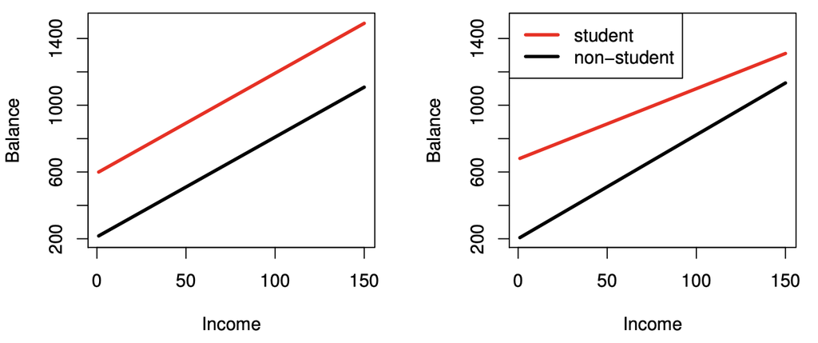

## 13 Potential Problems

### 13.1 Non-linear effects of predictors

- Assumption for the linear regression model: there is a straight-line relationship between the predictors and the response. What if the data violates this assumptions?
- `Auto` data.
- Linear fit vs polynomial fit.

**R**

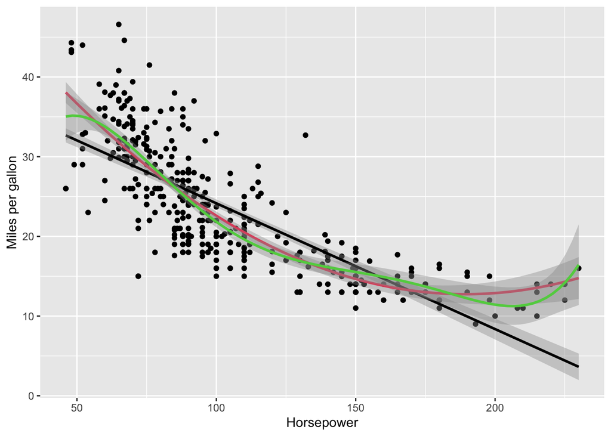

```r
ggplot(data = Auto, mapping = aes(x = horsepower, y = mpg)) +
  geom_point() +
  geom_smooth(method = lm, color = 1) +
  geom_smooth(method = lm, formula = y ~ poly(x, 2), color = 2) +
  geom_smooth(method = lm, formula = y ~ poly(x, 5), color = 3) +
  labs(x = "Horsepower", y = "Miles per gallon")
```

The figure suggests that `mpg` vs `horsepower` to have a quadratic shape. And the following model
$$\text{mpg} = \beta_0 + \beta_1 \times \text{horsepower} + \beta_2 \times \text{horsepower}^2 + \epsilon$$
may provide a better fit. But it is still a linear model! So we can use standard linear regression software to estimate $\beta_0$, $\beta_1$, $\beta_2$ in order to produce a non-linear fit.

**R**

```r
Auto <- as_tibble(Auto) %>% print(width = Inf)
```

```
# A tibble: 392 × 9
     mpg cylinders displacement horsepower weight acceleration  year origin
   <dbl>     <int>        <dbl>      <int>  <int>        <dbl> <int>  <int>
 1    18         8          307        130   3504         12      70      1
 2    15         8          350        165   3693         11.5    70      1
 3    18         8          318        150   3436         11      70      1
 4    16         8          304        150   3433         12      70      1
 5    17         8          302        140   3449         10.5    70      1
 6    15         8          429        198   4341         10      70      1
 7    14         8          454        220   4354          9      70      1
 8    14         8          440        215   4312          8.5    70      1
 9    14         8          455        225   4425         10      70      1
10    15         8          390        190   3850          8.5    70      1
   name
   <fct>
 1 chevrolet chevelle malibu
 2 buick skylark 320
 3 plymouth satellite
 4 amc rebel sst
 5 ford torino
 6 ford galaxie 500
 7 chevrolet impala
 8 plymouth fury iii
 9 pontiac catalina
10 amc ambassador dpl
# ℹ 382 more rows
```

```r
# Linear fit
lm(mpg ~ horsepower, data = Auto) %>% summary()
```

```
Call:
lm(formula = mpg ~ horsepower, data = Auto)

Residuals:
     Min       1Q   Median       3Q      Max
-13.5710  -3.2592  -0.3435   2.7630  16.9240

Coefficients:
             Estimate Std. Error t value Pr(>|t|)
(Intercept) 39.935861   0.717499   55.66   <2e-16 ***
horsepower  -0.157845   0.006446  -24.49   <2e-16 ***
---
Signif. codes:  0 '***' 0.001 '**' 0.01 '*' 0.05 '.' 0.1 ' ' 1

Residual standard error: 4.906 on 390 degrees of freedom
Multiple R-squared:  0.6059,    Adjusted R-squared:  0.6049
F-statistic: 599.7 on 1 and 390 DF,  p-value: < 2.2e-16
```

```r
# Degree 2
lm(mpg ~ poly(horsepower, 2), data = Auto) %>% summary()
```

```
Call:
lm(formula = mpg ~ poly(horsepower, 2), data = Auto)

Residuals:
     Min       1Q   Median       3Q      Max
-14.7135  -2.5943  -0.0859   2.2868  15.8961

Coefficients:
                      Estimate Std. Error t value Pr(>|t|)
(Intercept)            23.4459     0.2209  106.13   <2e-16 ***
poly(horsepower, 2)1 -120.1377     4.3739  -27.47   <2e-16 ***
poly(horsepower, 2)2   44.0895     4.3739   10.08   <2e-16 ***
---
Signif. codes:  0 '***' 0.001 '**' 0.01 '*' 0.05 '.' 0.1 ' ' 1

Residual standard error: 4.374 on 389 degrees of freedom
Multiple R-squared:  0.6876,    Adjusted R-squared:  0.686
F-statistic:   428 on 2 and 389 DF,  p-value: < 2.2e-16
```

```r
# Degree 5
lm(mpg ~ poly(horsepower, 5), data = Auto) %>% summary()
```

```
Call:
lm(formula = mpg ~ poly(horsepower, 5), data = Auto)

Residuals:
     Min       1Q   Median       3Q      Max
-15.4326  -2.5285  -0.2925   2.1750  15.9730

Coefficients:
                      Estimate Std. Error t value Pr(>|t|)
(Intercept)            23.4459     0.2185 107.308  < 2e-16 ***
poly(horsepower, 5)1 -120.1377     4.3259 -27.772  < 2e-16 ***
poly(horsepower, 5)2   44.0895     4.3259  10.192  < 2e-16 ***
poly(horsepower, 5)3   -3.9488     4.3259  -0.913  0.36190
poly(horsepower, 5)4   -5.1878     4.3259  -1.199  0.23117
poly(horsepower, 5)5   13.2722     4.3259   3.068  0.00231 **
---
Signif. codes:  0 '***' 0.001 '**' 0.01 '*' 0.05 '.' 0.1 ' ' 1

Residual standard error: 4.326 on 386 degrees of freedom
Multiple R-squared:  0.6967,    Adjusted R-squared:  0.6928
F-statistic: 177.4 on 5 and 386 DF,  p-value: < 2.2e-16
```

**Python**

```python
# Import Auto data (missing data represented by '?')
Auto = pd.read_csv("./slides/data/Auto.csv", na_values = '?').dropna()
Auto
```

```
      mpg  cylinders  displacement  horsepower  weight  acceleration  year  \
0    18.0          8         307.0       130.0    3504          12.0    70
1    15.0          8         350.0       165.0    3693          11.5    70
2    18.0          8         318.0       150.0    3436          11.0    70
3    16.0          8         304.0       150.0    3433          12.0    70
4    17.0          8         302.0       140.0    3449          10.5    70
..    ...        ...           ...         ...     ...           ...   ...
392  27.0          4         140.0        86.0    2790          15.6    82
393  44.0          4          97.0        52.0    2130          24.6    82
394  32.0          4         135.0        84.0    2295          11.6    82
395  28.0          4         120.0        79.0    2625          18.6    82
396  31.0          4         119.0        82.0    2720          19.4    82

     origin                       name
0         1  chevrolet chevelle malibu
1         1          buick skylark 320
2         1         plymouth satellite
3         1              amc rebel sst
4         1                ford torino
..      ...                        ...
392       1            ford mustang gl
393       2                  vw pickup
394       1              dodge rampage
395       1                ford ranger
396       1                 chevy s-10

[392 rows x 9 columns]
```

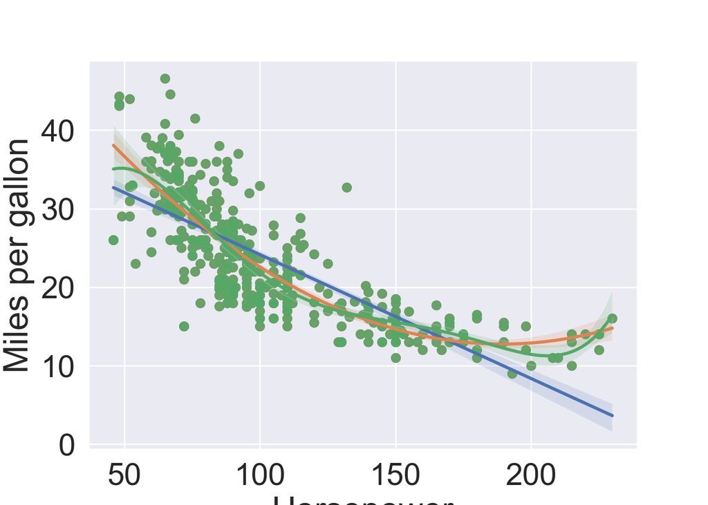

```python
plt.clf()
# Linear fit
ax = sns.regplot(
  data = Auto,
  x = 'horsepower',
  y = 'mpg',
  order = 1
  )
# Quadratic fit
sns.regplot(
  data = Auto,
  x = 'horsepower',
  y = 'mpg',
  order = 2,
  ax = ax
  )
# 5-degree fit
sns.regplot(
  data = Auto,
  x = 'horsepower',
  y = 'mpg',
  order = 5,
  ax = ax
  )
ax.set(
  xlabel = 'Horsepower',
  ylabel = 'Miles per gallon'
)
```

#### 13.1.1 Residual Plots

- A useful graphical tool for identifying non-linearity, outliers, etc.
- Recall residuals are
  $$\epsilon_i = y_i - \hat{y}_i$$
  Predicted/fitted values are
  $$\hat{y}_i = \mathbf{X}\hat{\beta}$$
- We plot the residuals versus the predicted (or fitted) values

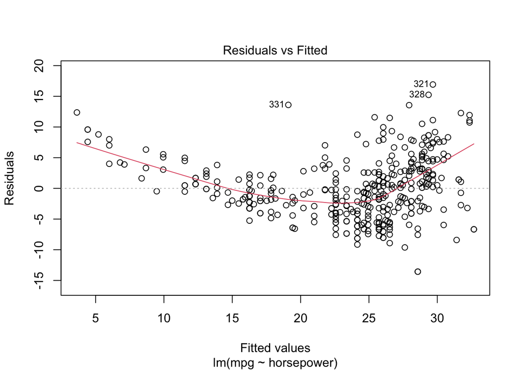

```r
# Linear fit
lm.fit <- lm(mpg ~ horsepower, data = Auto)
plot(lm.fit, which = c(1))
```

Ideally, the residual plot will show no discernible pattern. The presence of a pattern may indicate a problem with some aspect of the linear model.

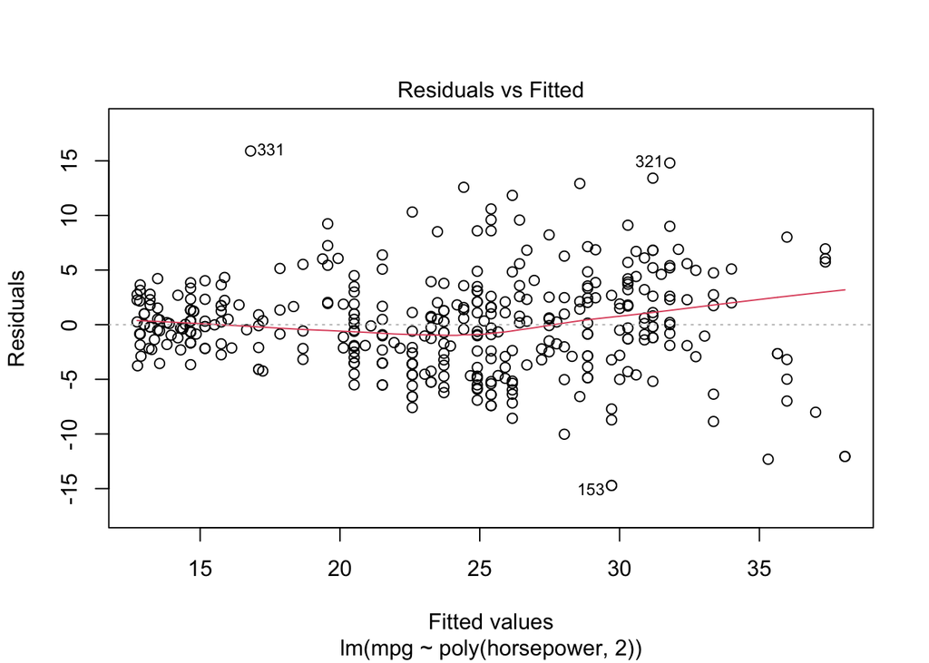

```r
# Linear fit
lm.df2.fit <- lm(mpg ~ poly(horsepower, 2), data = Auto)
plot(lm.df2.fit, which = c(1))
```

If the residual plot indicates that there are non-linear associations in the data, then a simple approach is to use non-linear transformations of the predictors, such as $\text{log}X$, $\sqrt{X}$, and $X^2$, in the regression model.

### 13.2 Correlation of error terms.

- One important assumption of the linear regression model is that the error terms, $\epsilon_1, \ldots, \epsilon_n$, are uncorrelated, e.g., longitudinal data, time series data, etc.

### 13.3 Non-constant variance of error terms.

- Another important assumption of the linear regression model is that the error terms have a constant variance, $\text{Var}(\epsilon_i) = \sigma^2$.
- Residual plot

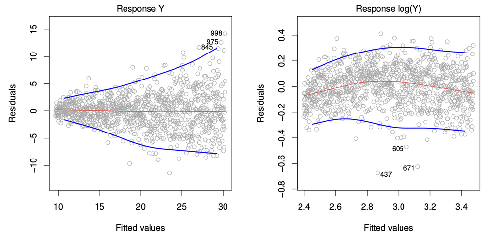

- Transformation of outcome or weighted least squares.

### 13.4 Outliers.

### 13.5 High leverage points.

### 13.6 Collinearity.

- Collinearity refers to the situation in which two or more predictor variables are closely related to one another.

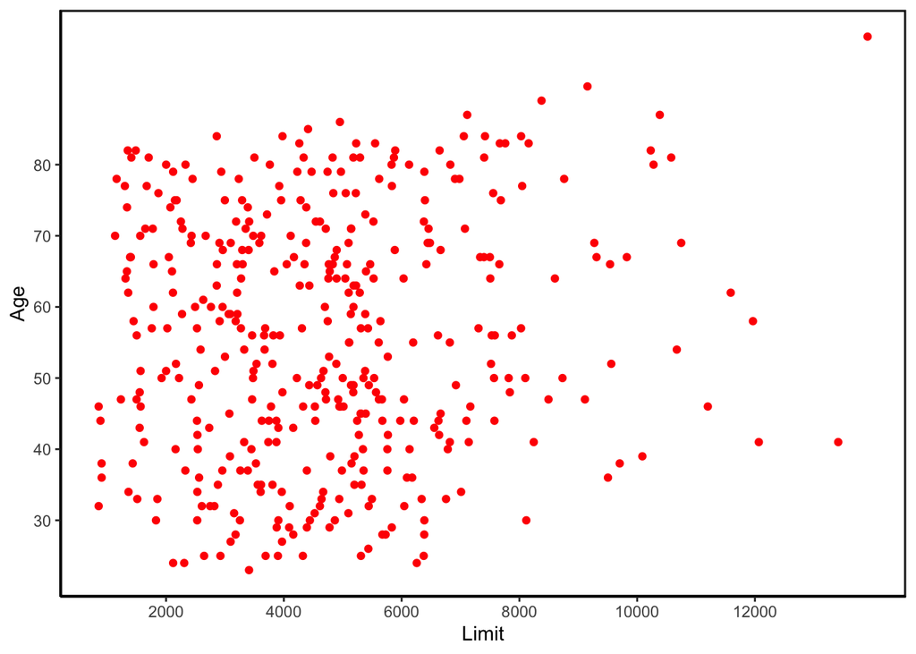

```r
library(ggplot2)
ggplot(Credit, aes(x = Limit, y = Age)) +  # Set up canvas with outcome variable on y-axis
  geom_point( color = "red") +
  scale_x_continuous(breaks = seq(2000, 12000, by = 2000)) + # Set x-axis limits
  scale_y_continuous(breaks = seq(30, 80, by = 10)) +
  xlab("Limit") +
  ylab("Age") +
  theme_bw() +
  theme(panel.background = element_rect(colour = "black", linewidth = 1),
        panel.grid.major = element_blank(),
        panel.grid.minor = element_blank(),
        axis.line = element_line(colour = "black"))
```

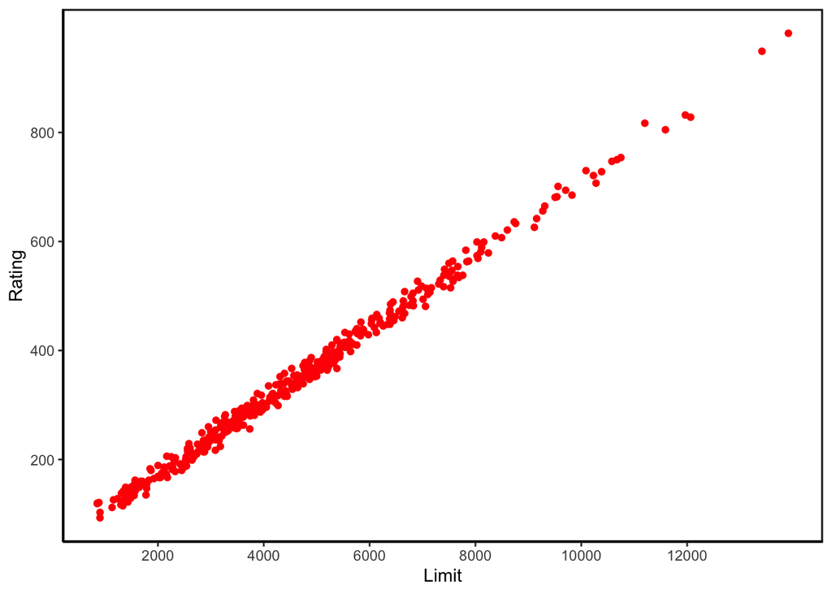

```r
ggplot(Credit, aes(x = Limit, y = Rating)) +  # Set up canvas with outcome variable on y-axis
  geom_point( color = "red") +
  scale_x_continuous(breaks = seq(2000, 12000, by = 2000)) + # Set x-axis limits
  scale_y_continuous(breaks = seq(200, 800, by = 200)) +
  xlab("Limit") +
  ylab("Rating") +
  theme_bw() +
  theme(panel.background = element_rect(colour = "black", linewidth = 1),
        panel.grid.major = element_blank(),
        panel.grid.minor = element_blank(),
        axis.line = element_line(colour = "black"))
```

- Collinearity reduces the accuracy of the estimates of the regression coefficients, it causes the standard error to grow.
- The power of the hypothesis test—the probability of correctly detecting a non-zero coefficient—is reduced by collinearity.
- Solution:
  - drop one of the problematic variables from the regression.
  - combine the collinear variables together into a single predictor.

## 14 Generalizations of linear models

In much of the rest of this course, we discuss methods that expand the scope of linear models and how they are fit.

- Classification problems: logistic regression, discriminant analysis, support vector machines.
- Non-linearity: kernel smoothing, splines and generalized additive models, nearest neighbor methods.
- Interactions: tree-based methods, bagging, random forests, boosting, neural networks (stacks of linear layers + nonlinearities).
- Regularized fitting: ridge regression and lasso (loss + penalty).
- Optimization & scaling: gradient descent / stochastic gradient descent for large-scale learning.